# ggplot2を利用したデータ可視化の基礎

### 5.4.2 種類ごとの色分け

種類ごとに分けて分布を作る場合は，aes()`の中で`fill`を設定する．

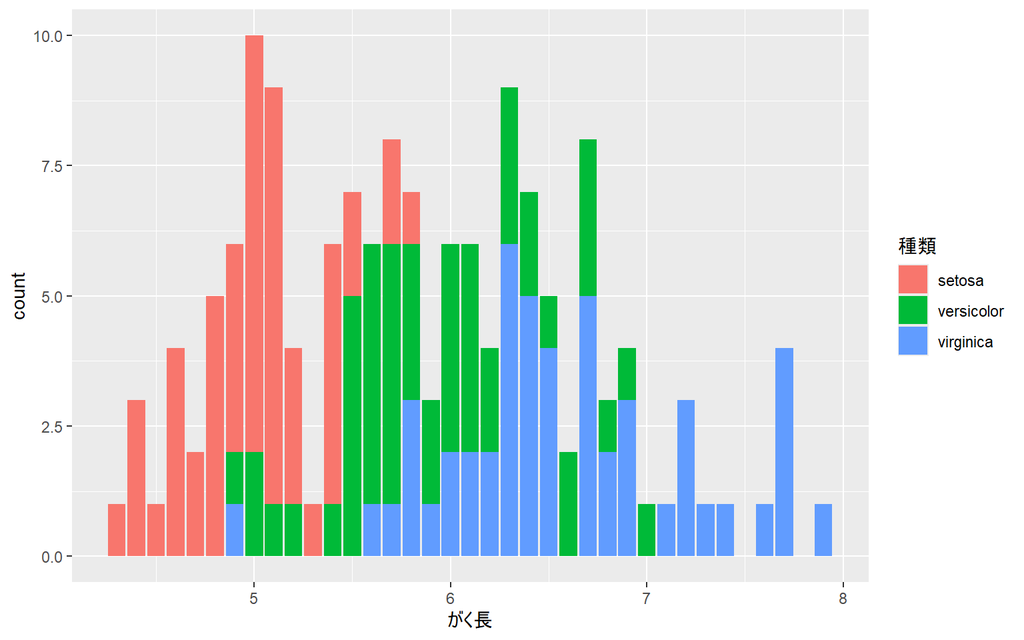

```r
g <- ggplot(data_iris)+
  geom_bar(aes(x=がく長, fill=種類),stat="count")
plot(g)
```

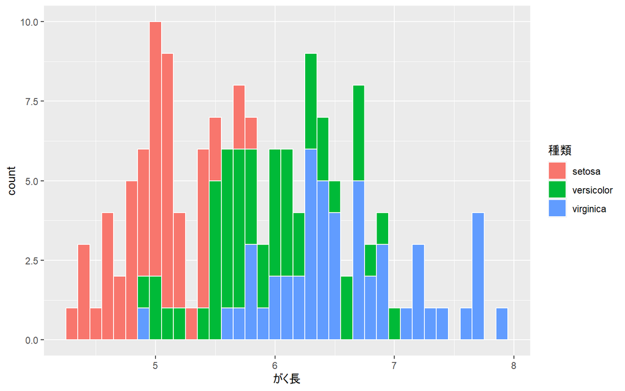

```r
g <- ggplot(data_iris)+
  geom_histogram(aes(x=がく長, fill=種類),color="white", binwidth = 0.1)
plot(g)
```

ただ，この場合，重なっている箇所については積み上げグラフになる．

### 5.4.3 種類別のヒストグラム作成

あくまで種類ごとにそれぞれ別々のヒストグラムにしたい，ということであれば，以下のように2つの方法が考えられる．

**方法1 データを端からバラバラにして3つのグラフを別々に描く**

この場合には，データを`filter()`関数(->参考)を用いて種類ごとに分け，それぞれを描画する．ただし，この場合，`coord_cartesian()` 関数を使ってx軸の変域を設定しないと，3つのグラフのx軸，y軸の変域がバラバラになってしまう．なので，以下の例のように，`coord_cartesian()`を使ってx軸，y軸の変域を設定する．

なお，`coord_cartesian()`と類似の働きをするものとしては，`xlim()`や`ylim()`があるが，`xlim()`や`ylim()`はデータそのものからこれらで指定した範囲外のものを除外する（結果として表示も指定範囲に限定される）のに対して，`coord_cartesian()`はデータを除外しているわけではなく，単に表示する範囲を指定するだけである．

単に表示を変えたいだけならば，`coord_cartesian()`を使うべきである．

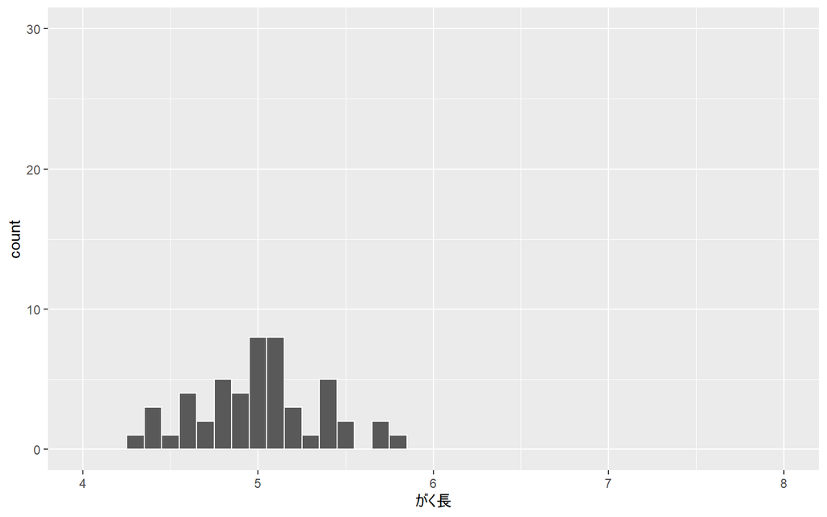

```r
g <- ggplot(filter(data_iris,種類=="setosa"))+
  geom_histogram(aes(x=がく長),color="white", binwidth = 0.1)+
  #xlim(4,8)+ylim(0,30)
  coord_cartesian(xlim = c(4, 8), ylim=c(0,30))
plot(g)
```

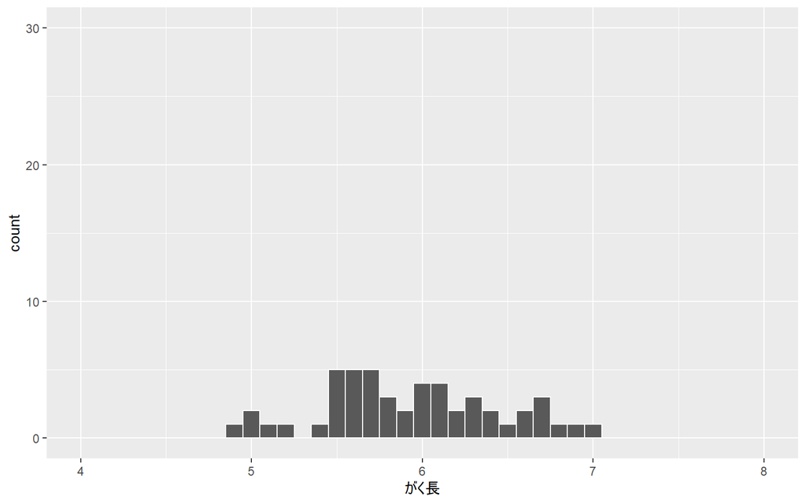

```r
g <- ggplot(filter(data_iris,種類=="versicolor"))+
  geom_histogram(aes(x=がく長),color="white", binwidth = 0.1)+
  #xlim(4,8)+ylim(0,30)
  coord_cartesian(xlim = c(4, 8), ylim=c(0,30))
plot(g)
```

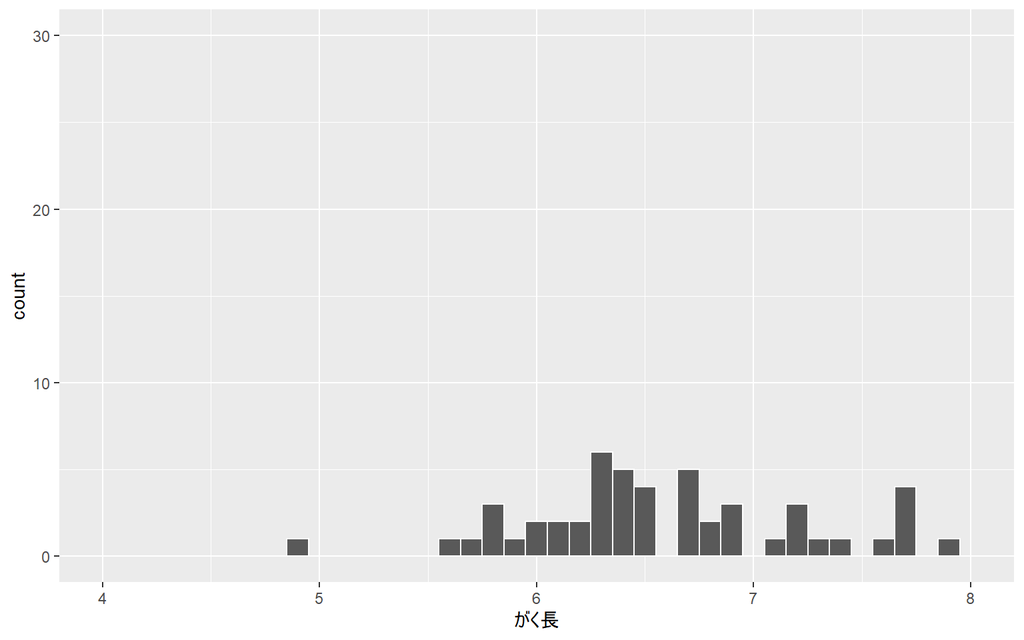

```r
g <- ggplot(filter(data_iris,種類=="virginica") )+
  geom_histogram(aes(x=がく長),color="white", binwidth = 0.1)+
  #xlim(4,8)+ylim(0,30)
  coord_cartesian(xlim = c(4, 8), ylim=c(0,30))
plot(g)
```

変数の内容を知るための関数として`str()`という関数がある．実際にこれを`filter()`関数の結果に対してかけてみると，以下の通りとなる．

```r
res<-filter(data_iris,種類=="setosa")
str(res)
```

```
## 'data.frame':    50 obs. of  5 variables:
##  $ がく長  : num  5.1 4.9 4.7 4.6 5 5.4 4.6 5 4.4 4.9 ...
##  $ がく幅  : num  3.5 3 3.2 3.1 3.6 3.9 3.4 3.4 2.9 3.1 ...
##  $ 花びら長: num  1.4 1.4 1.3 1.5 1.4 1.7 1.4 1.5 1.4 1.5 ...
##  $ 花びら幅: num  0.2 0.2 0.2 0.2 0.2 0.4 0.3 0.2 0.2 0.1 ...
##  $ 種類    : Factor w/ 3 levels "setosa","versicolor",..: 1 1 1 1 1 1 1 1 1 1 ...
```

データ点数は50点とあり，確かにsetosaのみを取り出せているのがわかる．一方で「種類」列の情報としては，この列は要因型であり，3つの水準（setosa, versicolorだけが表示されているが・・・）で構成されていることが記載されていることがわかる．

**方法2: 1つの絵の中で3つに分割して描く(`facet_wrap()`の利用)**

`facet_wrap()`を利用することで1枚のキャンバスを分割して表示させることができる．

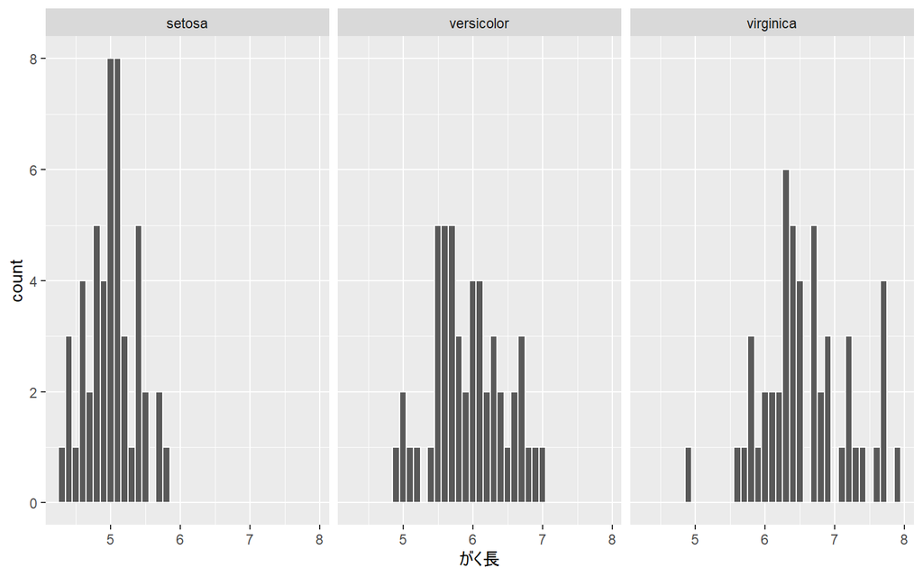

```r
g <- ggplot(data_iris)+
  geom_histogram(aes(x=がく長),color="white", binwidth = 0.1)+
  facet_wrap(~種類)
plot(g)
```

デフォルトでは，横方向（列方向）に分割されていくが，`nrow`(行数)を設定することによって縦方向（行方向）にも分割させることができる．

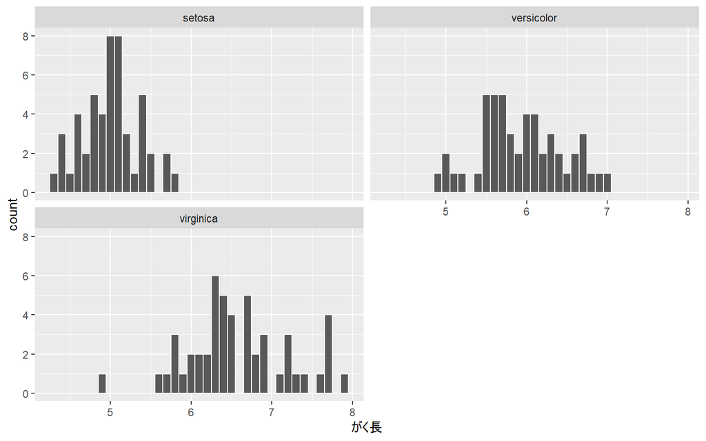

```r
g <- ggplot(data_iris)+
  geom_histogram(aes(x=がく長),color="white", binwidth = 0.1)+
  facet_wrap(~種類,nrow=2)
plot(g)
```

### 5.4.4 複数の変数のヒストグラム

これまで「がく長」について種類別のヒストグラムを描く方法を説明したが，今度は，複数の変数（例えば，「がく長」と「がく幅」）のヒストグラムを描く方法を説明する．

方法は大きく2つある． 1つは，シンプルに変数ごとに別々のキャンバスを用意して描画する方法である． 以下はその例．

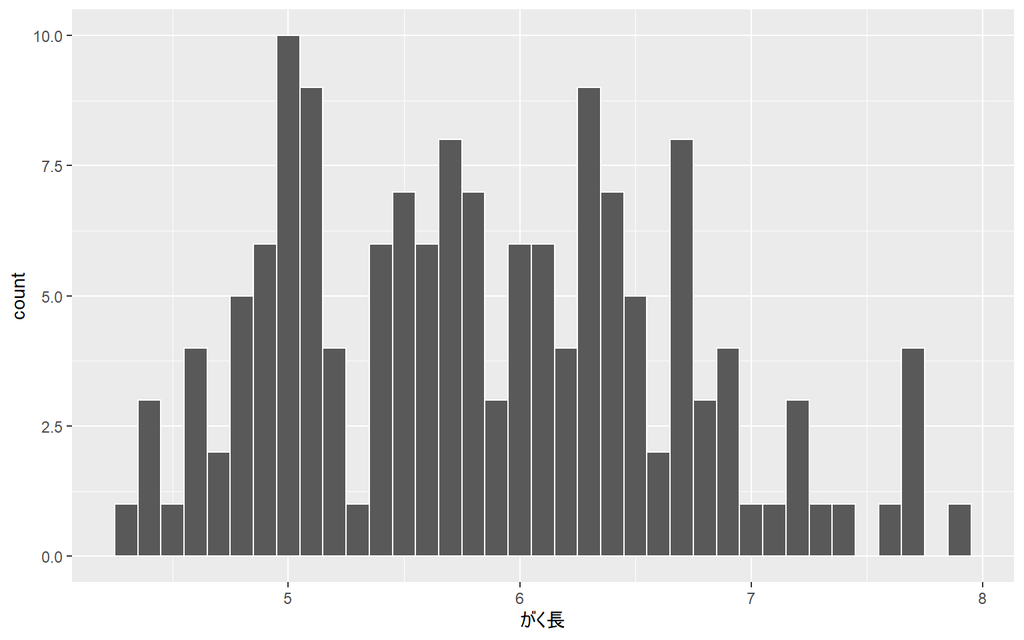

```r
g <- ggplot(data_iris)+
  geom_histogram(aes(x=がく長),color="white", binwidth = 0.1)
plot(g)
```

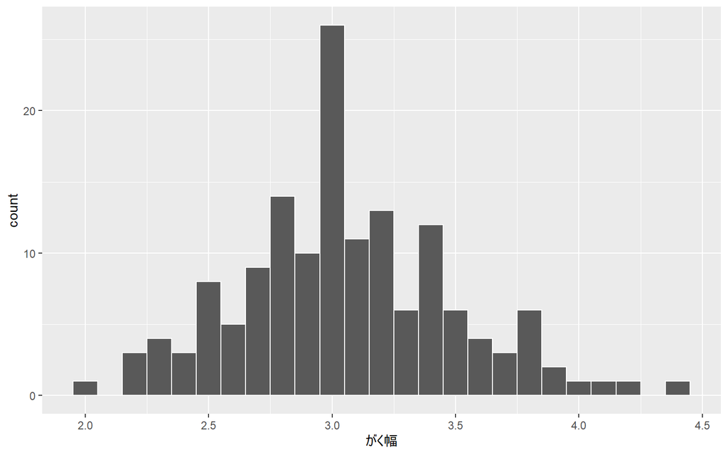

```r
g <- ggplot(data_iris)+
  geom_histogram(aes(x=がく幅),color="white", binwidth = 0.1)
plot(g)
```

もう1つは，`facet_wrap()`を使って1つのキャンバスに複数の変数のヒストグラムを描画する方法である． この場合は，ggplotに与えるデータをロング形式に変換する必要がある．すなわち，現状では，以下のような表になっているが

| 種類 | がく長 | がく幅 | 花びら長 | 花びら幅 |
| --- | --- | --- | --- | --- |
| setosa | 5.1 | 3.5 | 1.4 | 0.2 |
| setosa | 4.9 | 3.0 | 1.4 | 0.2 |
| setosa | 4.7 | 3.2 | 1.3 | 0.2 |
| … | … | … | … | … |

以下のように変換する必要がある．

| 種類 | 変数 | 値 |
| --- | --- | --- |
| setosa | がく長 | 5.1 |
| setosa | がく幅 | 3.5 |
| setosa | 花びら長 | 1.4 |
| setosa | 花びら幅 | 0.2 |
| setosa | がく長 | 4.9 |
| setosa | がく幅 | 3.0 |
| setosa | 花びら長 | 1.4 |
| setosa | 花びら幅 | 0.2 |
| setosa | がく長 | 4.7 |
| setosa | がく幅 | 3.2 |
| setosa | 花びら長 | 1.3 |
| setosa | 花びら幅 | 0.2 |
| … | … | … |

このように変換するためには，データハンドリングで紹介した`pivot_longer()`関数を使う．以下のようにする．

```r
data_iris_long <- pivot_longer(data_iris, cols=c(がく長, がく幅, 花びら長, 花びら幅), names_to="変数", values_to="値")
head(data_iris_long)
```

```
## # A tibble: 6 × 3
##   種類   変数        値
##   <fct>  <chr>    <dbl>
## 1 setosa がく長     5.1
## 2 setosa がく幅     3.5
## 3 setosa 花びら長   1.4
## 4 setosa 花びら幅   0.2
## 5 setosa がく長     4.9
## 6 setosa がく幅     3
```

変換が出来たら，filter関数で描画させたい変数のみを抽出したうえで，`geom_histgram()`と`facet_wrap()`を使って描画する．

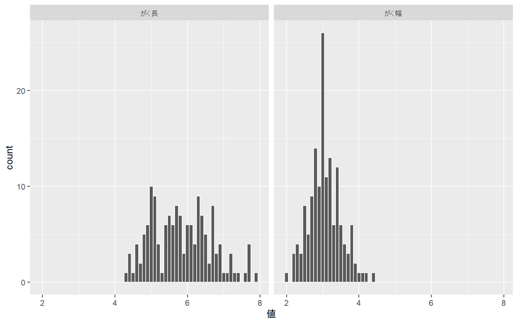

```r
g <- ggplot(filter(data_iris_long,変数=="がく長"|変数=="がく幅"))+
  geom_histogram(aes(x=値),color="white", binwidth = 0.1)+
  facet_wrap(~変数)
plot(g)
```

ただ，注意すべき点として，facet_wrap()を使う場合には，x軸の値域は全てのヒストグラムで同じものとなる．このため，上の図のように，明らかに個別の変数のデータとしてはデータが存在しない区間（がく長での4以下の区間や，がく幅での5以上区間）があっても，いずれかの変数でその区間にデータが存在すれば，すべての変数でその区間も含めた形のヒストグラムが描かれることになる．

ヒストグラムを比較することに意味があるなら，そのような表示でも問題はないが，比較するつもりはとくになく，それぞれの変数でヒストグラムを得たいだけならば，無理に1枚のキャンバスに描画しようとせずに，それぞれの変数ごとに別々に描画する方法をとる方がよいだろう．

先ほど読み込んだ大学入試共通テストの得点データ（数学IA，数学IIB，国語）を使って以下の問に答えよ．

1. 数学IA，数学IIB，国語の3科目についてのヒストグラムをそれぞれ別のグラフとして描画せよ．区間幅は5点刻みとする．
2. 数学IAについて地域別のヒストグラムを1枚のグラフとしてまとめたものをfacet_wrap()関数を用いて作成せよ．区間幅は5点刻みとする．

## 5.5 散布図

2つのデータの関係性を可視化するグラフの代表格は散布図である．散布図は点プロットで紹介した`geom_point()`を用いて以下のようにして描く．

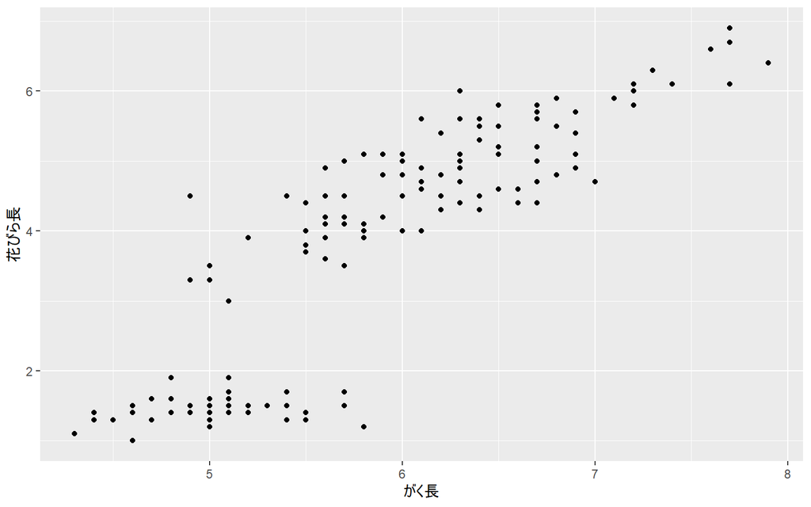

```r
g <- ggplot(data_iris)+
  geom_point(aes(x=がく長, y=花びら長))
plot(g)
```

### 5.5.1 種類ごとに色分け

`geom_point()`の`aes()`に`color`を与える．

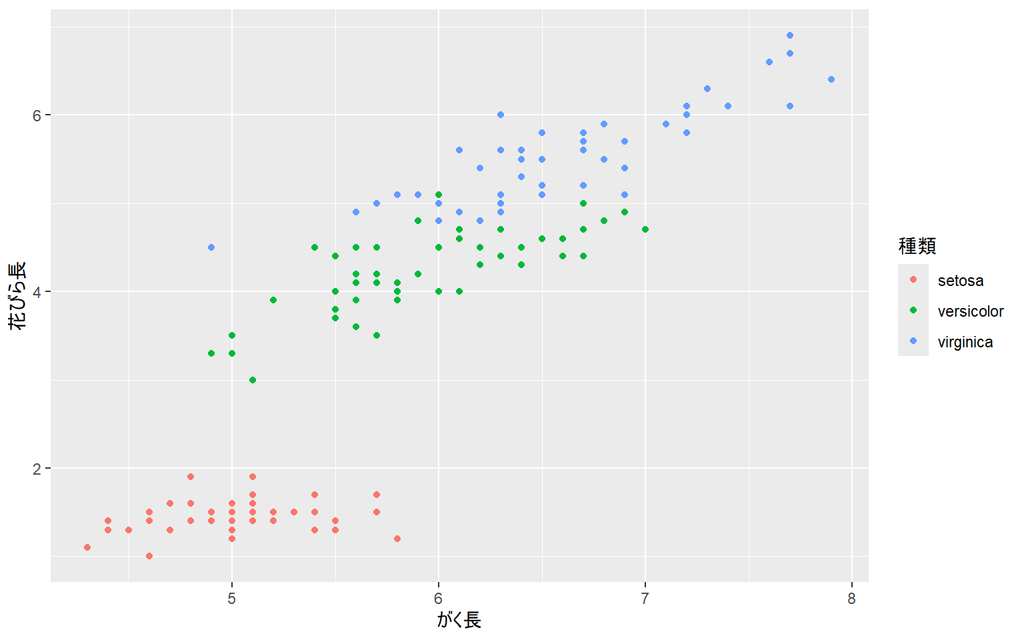

```r
g <- ggplot(data_iris)+
  geom_point(aes(x=がく長, y=花びら長, color=種類))
plot(g)
```

### 5.5.2 種類ごとにプロットの形を分ける

`geom_point()`の`aes()`に`shape`を与える．

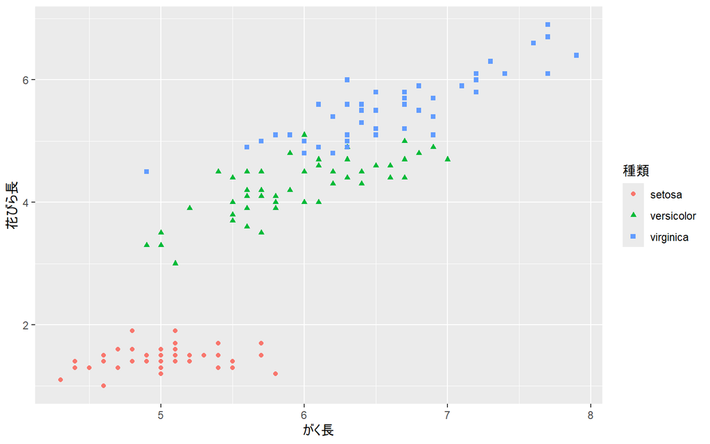

```r
g <- ggplot(data_iris)+
  geom_point(aes(x=がく長, y=花びら長, color=種類, shape=種類))
plot(g)
```

分かりやすく，がく長と花びら長に関係性として，setosaにはほぼ関係性はないが，versicolorとvirginicaにはがく長が長くなると，花びら長も長くなる傾向にあることが分かった．

散布図は回帰分析を行う際の結果の可視化でも改めて触れることにする．

## 5.6 任意の位置に文字や図形を書き入れる

任意の場所に任意の文字や線，図形を書き入れる場合には，`annotate()`関数を使う．以下のように，`geom_point()`の後に`annotate()`を使って，任意の位置に任意の文字を書き入れることができる．以下に代表的な引数を示す．これら以外にも円を描いたり，矢印を描いたりできるので，興味がある人はChatGPTに聞いてみてほしい．

| 引数名 | 内容 |
| --- | --- |
| 第1引数 | アノテーションの種類の指定．“text”(テキスト)，“segment”(線分)，“rect”(四角形)などがある |
| x,y | アノテーションを書き入れるx,y座標 |
| xend | 線を引く場合の終点のx座標 |
| yend | 線を引く場合の終点のy座標 |
| xmin, xmax, ymin, ymax | 四角形を描く場合の座標 |
| label | 書き入れる文字列 |
| color | 文字の色，線の色 |
| fill | 四角形の塗りつぶしの色 |
| size | 文字の大きさ |
| angle | 文字の角度 |
| linewidth | 線の幅 |

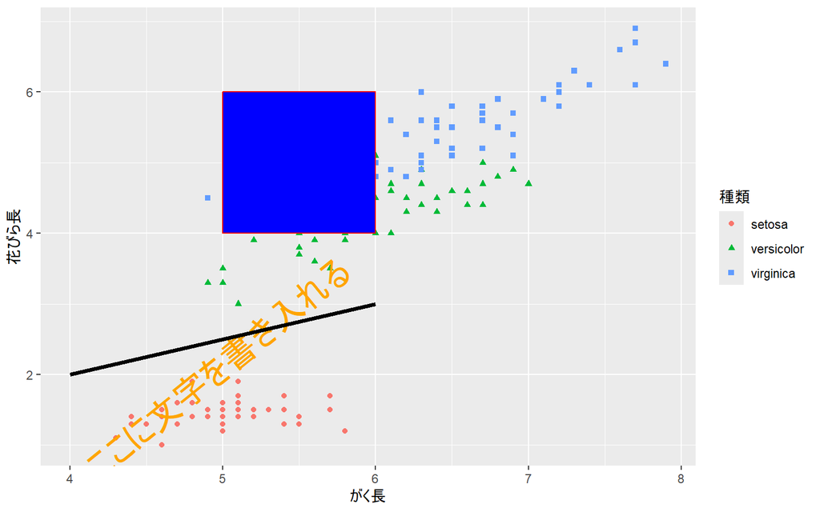

```r
g <- ggplot(data_iris)+
  geom_point(aes(x=がく長, y=花びら長, color=種類, shape=種類))+
  annotate("text", x=5, y=2, label="ここに文字を書き入れる",color="orange",size=7, angle=39)+
  annotate("segment", x=4, y=2, xend=6, yend=3, linewidth=1.5)+
  annotate("rect", xmin=5, xmax=6, ymin=4, ymax=6,color="red",fill="blue")
plot(g)
```

先ほど読み込んだ大学入試共通テストの得点データ（数学IA，数学IIB，国語）を使って以下の問に答えよ．

1. 数学IAをx軸，国語をy軸とする散布図を作成せよ．
2. 上で作成した散布図について，地域別の色分けを行え．
3. 上で作成した散布図に対して，annotationの`segment`を用いて，数学の平均点を示すY軸に平行な線分と国語の平均点を示すx軸に並行な線分を引け.
4. 上で作成した線分の入った散布図に対して，線分をx軸，y軸と見立てて，annotationの`text`を用いて，「第1象限」から「第4象限」までを，それぞれ該当する象限の中の任意の位置に記述せよ．

# 6 タイトルや凡例を弄る

## 6.1 軸のタイトルを消したり書き換えたり

デフォルトでは軸タイトルは`aes()`で設定した各軸の変数名がそのまま入るが，`xlab`や`ylab`を使って自分の好きなように変えることができる． 引数に`NULL`を設定すると軸タイトルを消せる．

以下では，x軸のタイトルを消し，y軸のタイトルを「がく長」に書き換えている．

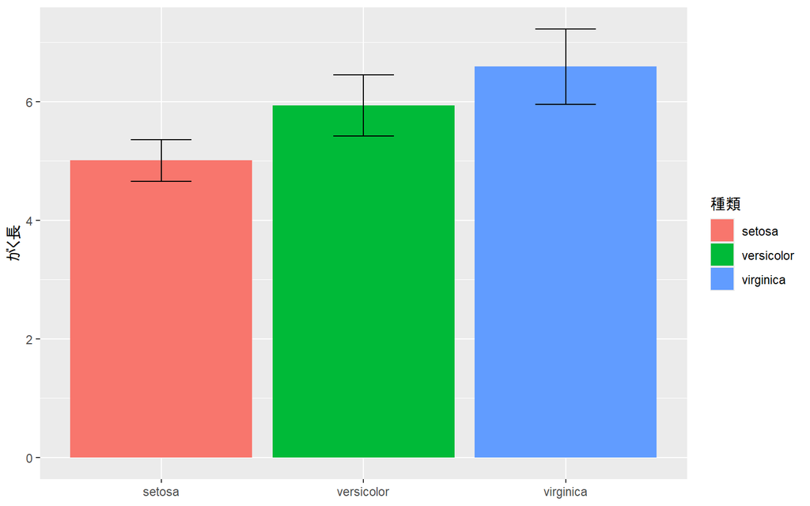

```r
g <- ggplot(d2,aes(x=種類,y=平均))+
  geom_bar(aes(fill=種類),stat="identity")+
  geom_errorbar(aes(ymin=平均-標準偏差, ymax=平均+標準偏差,width=0.3))+
  xlab(NULL)+ylab("がく長")
plot(g)
```

## 6.2 凡例タイトルを書き換える

`labs()`を使う． 引数には，`aes()`で色を指定するときに使った引数に，書き換えたいタイトルを与える． 以下の例では，`fill`を使って色を与えているので，`fill=****`というのを引数としてlabelに与える．

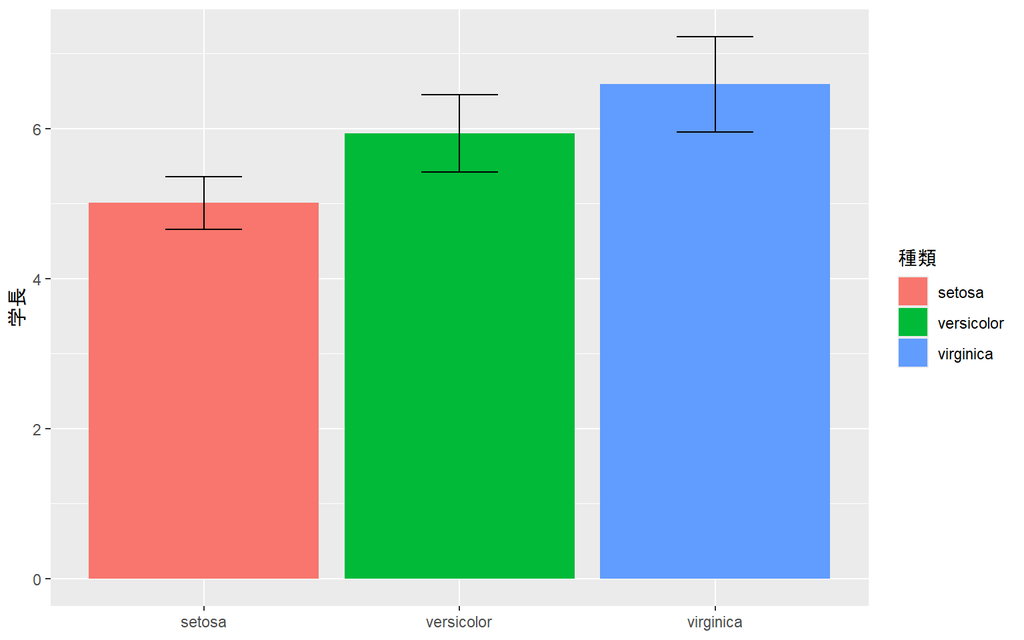

```r
g <- ggplot(d2,aes(x=種類,y=平均))+
  geom_bar(aes(fill=種類),stat="identity")+
  geom_errorbar(aes(ymin=平均-標準偏差, ymax=平均+標準偏差,width=0.3))+
  xlab(NULL)+ylab("学長")+labs(fill="種類")
plot(g)
```

ちなみにlabsは引数として以下のものを取る．

| 項目 | 内容 |
| --- | --- |
| title | タイトル |
| subtitle | サブタイトル |
| x | x軸ラベル |
| y | y軸ラベル |
| caption | キャプション |
| fill またはcolor | 凡例ラベルのタイトル |

この通りに，xlabやylabもlabsでまとめて設定することもできる．

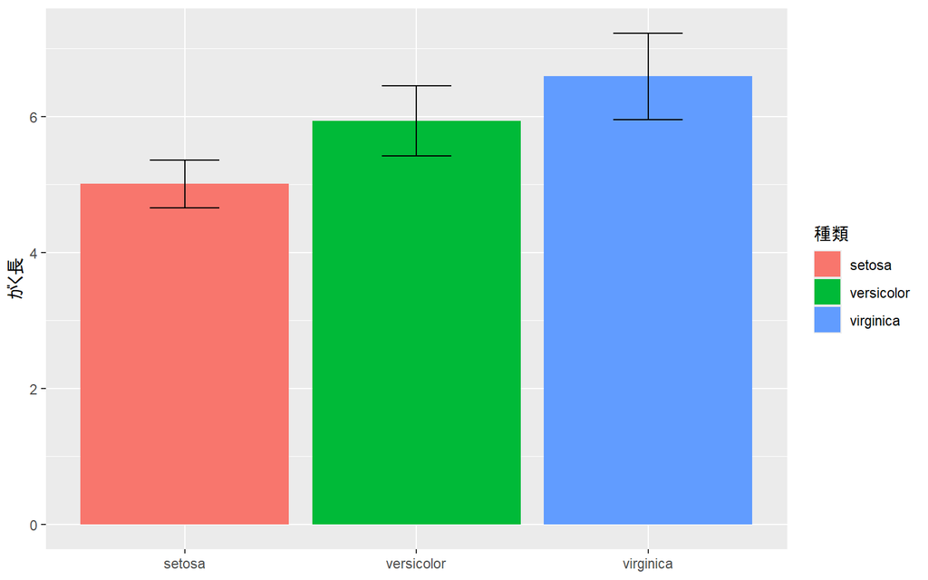

```r
g <- ggplot(d2,aes(x=種類,y=平均))+
  geom_bar(aes(fill=種類),stat="identity")+
  geom_errorbar(aes(ymin=平均-標準偏差, ymax=平均+標準偏差,width=0.3))+
  labs(x=NULL, y="がく長", fill="種類")
plot(g)
```

## 6.3 凡例を消す

`theme(legend.position = "none")`を使う．

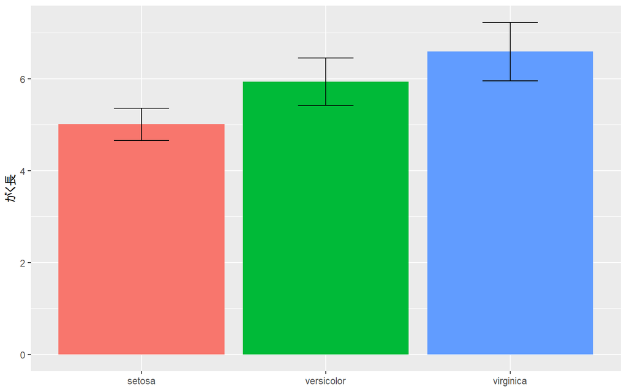

```r
g <- ggplot(d2,aes(x=種類,y=平均))+
  geom_bar(aes(fill=種類),stat="identity")+
  geom_errorbar(aes(ymin=平均-標準偏差, ymax=平均+標準偏差,width=0.3))+
  xlab(NULL)+ylab("がく長")+
  theme(legend.position = "none")
plot(g)
```

## 6.4 軸タイトルや軸ラベル，凡例の文字サイズを換える

凡例を消した時と同じようにthemeを使う．引数には以下のようなものを入れる． `axis.text.x=element_text(size=15)` `axis.text.y=element_text(size=15)` `axis.title.x=element_text(size=15)` `axis.title.y=element_text(size=15)` `legend.text=element_text(size=9)`

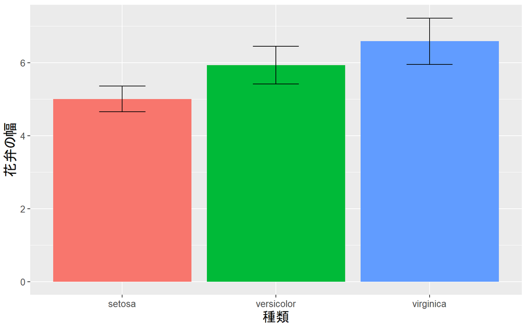

```r
g <- ggplot(d2,aes(x=種類,y=平均))+
  geom_bar(aes(fill=種類),stat="identity")+
  geom_errorbar(aes(ymin=平均-標準偏差, ymax=平均+標準偏差,width=0.3))+
  xlab("種類")+ylab("花弁の幅")+
  theme(legend.position = 'none')+
  theme(
    axis.title.x=element_text(size=15),
    axis.title.y=element_text(size=15),
    axis.text.x=element_text(size=10),
    axis.text.y=element_text(size=10),
    legend.text=element_text(size=5),
    legend.title = element_text(size=8)  )

plot(g)
```

**themeの設定項目**

themeは細かくいろいろ設定できる．設定できるものは以下の通り．

| 名前 | 説明 | 要素の型 |
| --- | --- | --- |
| text | すべてのテキスト要素 | element_text() |
| axis.title | 両軸ラベルの体裁 | element_text() |
| axis.title.x | x軸ラベルの体裁 | element_text() |
| axis.title.y | y軸ラベルの体裁 | element_text() |
| axis.text | 両軸目盛ラベルの体裁 | element_text() |
| axis.text.x | x軸目盛ラベルの体裁 | element_text() |
| axis.text.y | y軸目盛ラベルの体裁 | element_text() |
| legend.text | 凡例項目の体裁 | element_text() |
| legend.title | 凡例タイトルの体裁 | element_text() |
| plot.title | タイトルの体裁 | element_text() |
| strip.text | 両方向ファセットラベルテキストの体裁 | element_text() |
| strip.text.x | 水平方向ファセットラベルテキストの体裁 | element_text() |
| strip.text.y | 垂直方向ファセットラベルテキストの体裁 | element_text() |
| legend.position | 凡例の位置 | left, right, bottom, top, c(x,y) :x,yは0~1 |
| legend.background | 凡例の背景 | element_rect(fill=“xxx”, color=“yyy”) fillは塗りつぶし，colorは枠線 |
| plot.background | プロット全体の背景 | element_rect(fill=“xxx”, color=“yyy”) |
| panel.background | プロット領域の背景 | element_rect() |
| panel.border | プロット領域の枠線 | element_rect(linetype=“xxx”) |
| rect | 全ての長方形要素 | element_rect() |
| panel.grid.major | 主目盛線 | element_line() |
| panel.grid.major.x | 主目盛線の垂直方向 | element_line() |
| panel.grid.major.y | 主目盛線の水平方向 | element_line() |
| panel.grid.minor | 補助目盛線 | element_line() |
| panel.grid.minor.x | 補助目盛線の垂直方向 | element_line() |
| panel.grid.minor.y | 補助目盛線の水平方向 | element_line() |
| axis.line | 軸に沿った線 | element_line() |
| line | すべての線要素 | element_line() |

引用（順序は改変しました）：https://knknkn.hatenablog.com/entry/2019/02/23/181311

**element_text()の設定項目**

| 設定項目 | element_text()の引数 |
| --- | --- |
| 角度 | angle |
| 水平位置 | hjust(0:左揃え～1:右揃え) |
| 垂直位置 | vjust(0:下揃え～1:上揃え) |
| サイズ | size |
| 色 | color |
| スタイル | face(bold or italic) |
| フォントファミリー | family |

参考：http://mukkujohn.hatenablog.com/entry/2016/10/11/220722

**element_xxxのその他の項目**

`element_rect(fill, color, size, linetype, inherit.blank)` — 長方形

| 項目 | 内容 |
| --- | --- |
| fill | 塗りつぶしの色 |
| color | 枠の色 |

`element_line(color, size, linetype, lineend, arrow, inherit.blank)`— 線

`element_blank()` — 空 消したい要素にはこれを指定する

参考：https://heavywatal.github.io/rstats/ggplot2.html

## 6.5 表示範囲（x軸，y軸の変域）を変える

すでにこちらで説明したとおり，グラフの表示範囲を限定したい場合には，`coord_cartesian()`を使う．代表的な引数は以下の2つである．

- xlim : x軸の表示範囲のベクトルデータ．c(最小値,最大値)で指定する．
- ylim : y軸の表示範囲のベクトルデータ．c(最小値,最大値)で指定する．

## 6.6 目盛ラベルを変える

目盛ラベルを変えるには，`scale_x_****`や`scale_y_***`を使う． 以下は，x軸の目盛りをsetosa, versicolor, virgnicaから，a, b, cに変え，y軸を普通の目盛から対数目盛に変えた例である．

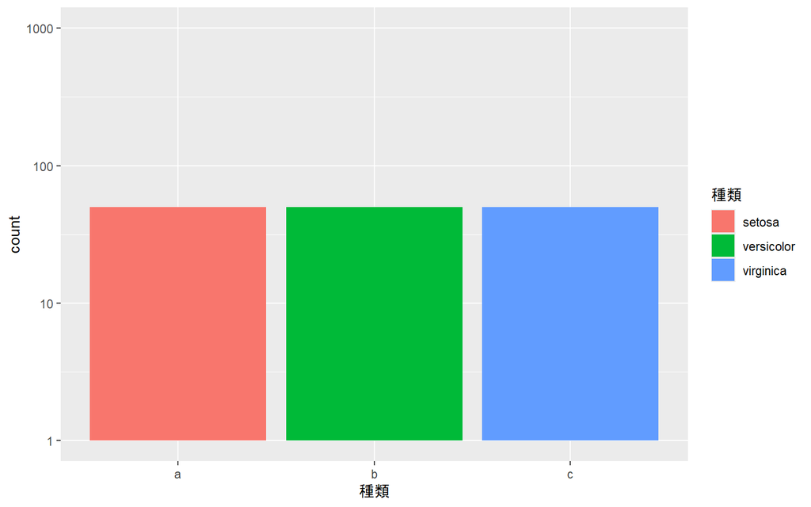

```r
g <- ggplot(data_iris)+
  geom_bar(aes(x=種類,fill=種類),stat="count") +
  scale_x_discrete(labels=c("a","b","c"))+
  scale_y_log10(limits=c(1,1000))
plot(g)
```

`***`の部分には，いずれも以下のものが入る．

| *** | 内容 |
| --- | --- |
| discrete | 離散目盛 |
| continuous | 連続目盛 |
| log10 | 対数目盛 |
| reverse | 目盛の逆転 |
| sqrt | 平方根目盛 |

また，代表的な引数としては以下のものが入る．

| 引数 | 内容 |
| --- | --- |
| labels | 離散目盛のラベルを変える（以下のbreaksを併用すると，連続変数でも可能） |
| breaks | 連続変数の目盛のうち指定したものだけを表示させる |
| limits | 連続変数の表示範囲を指定したものにする.xlim,ylimと同じ効果． |
| name | 変数の軸ラベルを変える．xlab,ylabと同じ効果． |

ちなみに，`xlim`や`ylim`は内部では`scale_x_continuous(limits=...)`や`scale_y_continuous(limits=)`を使っている．このため，これらはデータそのものを除外しており，結果として表示範囲も変わるという仕組みになっている．単に表示範囲を変えたいだけであれば，`coord_cartesian()`を使う方がよい．

結局，軸タイトルを変える方法って，色々あるということである． xlabでもよいし，labs(x=)dでもよいし，scale_x_***(name=)でも変えれる．